# Weather Event Analysis using NOAA Storm Database to determine greatest impact weather event *types*.

Gabriel Moreno

20 February 2015

## Synopsis

The aim of this analysis is to explore the NOAA Storm Database and answer the following two questions in regards to severe weather events:

1. Across the United States, which types of events are the most harmful with respect to population health?
2. Across the United States, which types of events have the greatest economic consequences?

The data was obtained from the NOAA Storm Database. Although the NOAA data contains observations from 1950 through to November 2011, only data observations from 1996 onward, was utilised. This is due to a new recording protocol being in place form 1996 onward, which recordered all types of weather events.

The analysis has resulted in the identification of TORNADO type events being the most harmful to population health and FLOOD type events as having the greatest economic impact.

## Data Processing

### Prelimanaries

This section is used to load any R libraries that will be required in this analysis. It is better to keep here rather than interrupt the flow of the analysis.

```r
# List of packages that are required for this analysis
list.of.packages <- c("plyr", "car", "lattice")

# check to see if required packages are installed
new.packages <- list.of.packages[!(list.of.packages %in% installed.packages()[,"Package"])]

# install missing packages
if(length(new.packages)) install.packages(new.packages)

# Load the plyr package
library("plyr")

# Load the car package
library(car)
# Load the lattice package
library(lattice)
```

### Load Data

The data for this analysis come in the form of a comma-separated-value file compressed via the bzip2 algorithm to reduce its size. The file was obtained from the Coursera Reproducible Research course website.

*Note the data file is quite large so avoid downloading unless necessary*. A link is provided for reference only [Storm Data](https://d396qusza40orc.cloudfront.net/repdata%2Fdata%2FStormData.csv.bz2) (4.7M).

Documentation containing information on how some of the variables are constructed/defined is available from National Weather Service [Storm Data Documentation](https://d396qusza40orc.cloudfront.net/repdata%2Fpeer2_doc%2Fpd01016005curr.pdf). In addition the following document is available National Climatic Data Center Storm Events [FAQ](https://d396qusza40orc.cloudfront.net/repdata%2Fpeer2_doc%2FNCDC%20Storm%20Events-FAQ%20Page.pdf)

*It has been noted that the events in the database start in the year 1950 and end in November 2011. In the earlier years of the database there are generally fewer events recorded, most likely due to a lack of good records. Data from more recent years should be considered more complete.*

Further investigation from the [NOAA Storm Event - Details](http://www.ncdc.noaa.gov/stormevents/details.jsp) webpage reveals:

Event Types Available:

1. Tornado: From 1950 through 1954, only tornado events were recorded.
2. Tornado, Thunderstorm Wind and Hail: From 1955 through 1992, only tornado, thunderstorm wind and hail events were keyed from the paper publications into digital data. From 1993 to 1995, only tornado, thunderstorm wind and hail events have been extracted from the [Unformatted Text Files](http://www.ncdc.noaa.gov/stormevents/details.jsp?type=collection).
3. All Event Types (48 from Directive 10-1605): From 1996 to present, 48 event types are recorded as defined in [NWS Directive 10-1605](http://www.ncdc.noaa.gov/stormevents/pd01016005curr.pdf).

*In light of the given information, only data from 1996 onwards will be analysed. Including earlier data would skew the results towards the subset of event types that where only recorder prior to 1996. In addition, although depreciation will not be accounted for in considering dollar vale for damage, restricting the data set to a smaller economic time frame (15 years) will be a better comparison than over a 61 year period.*

```r
# Check if we have run this before and still have the data loaded (big file)
if (!exists("stormData")) {
  dataSourceFileName <- "repdata-data-StormData.csv.bz2"
  # Check if we have already downloaded the source data file from the URL
  if (!file.exists(dataSourceFileName)) {
    fileUrl <- "https://d396qusza40orc.cloudfront.net/repdata%2Fdata%2FStormData.csv.bz2"
    download.file(fileUrl, destfile = dataSourceFileName, method = "curl", quiet = TRUE)
  }
  # First time for everything :)
  stormData <- read.csv(dataSourceFileName)
}
```

### Review Data

Let’s look at how the data is structured.

```r
str(stormData)
```

```
## 'data.frame':    902297 obs. of  37 variables:
##  $ STATE__   : num  1 1 1 1 1 1 1 1 1 1 ...
##  $ BGN_DATE  : Factor w/ 16335 levels "1/1/1966 0:00:00",..: 6523 6523 4242 11116 2224 2224 2260 383 3980 3980 ...
##  $ BGN_TIME  : Factor w/ 3608 levels "00:00:00 AM",..: 272 287 2705 1683 2584 3186 242 1683 3186 3186 ...
##  $ TIME_ZONE : Factor w/ 22 levels "ADT","AKS","AST",..: 7 7 7 7 7 7 7 7 7 7 ...
##  $ COUNTY    : num  97 3 57 89 43 77 9 123 125 57 ...
##  $ COUNTYNAME: Factor w/ 29601 levels "","5NM E OF MACKINAC BRIDGE TO PRESQUE ISLE LT MI",..: 13513 1873 4598 10592 4372 10094 1973 23873 24418 4598 ...
##  $ STATE     : Factor w/ 72 levels "AK","AL","AM",..: 2 2 2 2 2 2 2 2 2 2 ...
##  $ EVTYPE    : Factor w/ 985 levels "   HIGH SURF ADVISORY",..: 834 834 834 834 834 834 834 834 834 834 ...
##  $ BGN_RANGE : num  0 0 0 0 0 0 0 0 0 0 ...
##  $ BGN_AZI   : Factor w/ 35 levels "","  N"," NW",..: 1 1 1 1 1 1 1 1 1 1 ...
##  $ BGN_LOCATI: Factor w/ 54429 levels ""," Christiansburg",..: 1 1 1 1 1 1 1 1 1 1 ...
##  $ END_DATE  : Factor w/ 6663 levels "","1/1/1993 0:00:00",..: 1 1 1 1 1 1 1 1 1 1 ...
##  $ END_TIME  : Factor w/ 3647 levels ""," 0900CST",..: 1 1 1 1 1 1 1 1 1 1 ...
##  $ COUNTY_END: num  0 0 0 0 0 0 0 0 0 0 ...
```

[output cut: 23 more lines]

The data set appears to contain **902297** observations and **37** variables. The variables of interest are:

- **BGN_DATE** is of type Factor and contains the date in the following character format: “%m/%d/%Y %H:%M:%S”
- **EVTYPE** is of type Factor and contains the name of weather event type;
- **FATALITIES** is of type num and contains the number of fatalities for the observed event;
- **INJURIES** is of type num and contains the number of injuries for the observed event;
- **PROPDMG** is of type num and contains the numeral portion of the property damage $ value for the observed event;
- **PROPDMGEXP** is of type Factor and contains the exponential portion of the property damage $ value for the observed event;
- **CROPDMG** is of type num and contains the numeral portion of the crop damage $ value for the observed event;
- **CROPDMGEXP** is of type Factor and contains the exponential portion of the property damage $ value for the observed event;

### Data Prep - Step 1 - Subset Data

The **BGN_DATE** variable will be converted to date format to allow sub-setting of data from 1996 onward. In addition observations that do not contain meaningful data will be excluded.

```r
# Convert BGN_DATE field from Factor to Date format
stormData$BGN_DATE <- as.Date(stormData$BGN_DATE, "%m/%d/%Y %H:%M:%S")
stormDataSub <- stormData[(stormData$BGN_DATE >= as.Date("1996/01/01")),]
dim(stormDataSub)
```

```
## [1] 653530     37
```

```r
# remove any observations that do not have any meaningful data
# (that is one of the variables must be greater than 0)
stormDataSub <- with(stormDataSub, stormDataSub[((FATALITIES>0)|(INJURIES>0)|(CROPDMG>0)|(PROPDMG>0)),])
dim(stormDataSub)
```

```
## [1] 201318     37
```

Sub-setting our data to weather events recorded from 1996 onward, has reduced our data set to **653530**, down from the original **902297** observations in the raw data set. Excluding any observations that did not contain any meaningful data, that is at least one of the variables being greater than 0, further reduced the data set to **201318** observations.

### Data Prep - Step 2 - Resolving the Value fields

Some processing of the dollar value fields is required due the exponential representation across two variables i.e. **PROPDMG** & **PROPDMGEXP** as well as **CROPDMG** & **CROPDMGEXP**. The [Storm Data Documentation](https://d396qusza40orc.cloudfront.net/repdata%2Fpeer2_doc%2Fpd01016005curr.pdf), describes the field encoding as follows:

“*Estimates should be rounded to three significant digits, followed by an alphabetical character signifying the magnitude of the number, i.e., 1.55B for $1,550,000,000. Alphabetical characters used to signify magnitude include “K” for thousands, “M” for millions, and “B” for billions*”

A calculation is required that takes both the numeric value and the exponential value and combines to obtain the total result. Let’s look at what the **xxxEXP** variables contain.

```r
count(stormDataSub, "PROPDMGEXP")
```

```
##   PROPDMGEXP   freq
## 1              8448
## 2          B     32
## 3          K 185474
## 4          M   7364
```

```r
count(stormDataSub, "CROPDMGEXP")
```

```
##   CROPDMGEXP   freq
## 1            102767
## 2          B      2
## 3          K  96787
## 4          M   1762
```

Both xxxEXP variables contain observations without entries to these variables. It will be assumed that, a “no entry” for xxxEXP will mean “no exponent is required”. On this basis combine the xxxDMG and xxxDMGEXP entries into a single number representing the actual value for the event. That is to achieve: PROPDMG * PROPDMGEXP = PROPDMGTOT

```r
# create some new fields for the results
stormDataSub$PROPDMGEXP2 <- as.numeric(NA)
stormDataSub$CROPDMGEXP2 <- as.numeric(NA)
stormDataSub$PROPDMGTOT <- as.numeric(NA)
stormDataSub$CROPDMGTOT <- as.numeric(NA)
stormDataSub$DMGTOT <- as.numeric(NA)
stormDataSub$HTHTOT <- as.numeric(NA)

# Work on Property Damage
# recode the factors from Letters to Values
stormDataSub$PROPDMGEXP2 <- recode(stormDataSub$PROPDMGEXP, "'0'=1;''=1;'K'=1000;'M'=1000000;'B'=1000000000",
                                   as.factor.result = FALSE, as.numeric.result=TRUE)
# calculate the total $ value using the exponential "value"
stormDataSub$PROPDMGTOT <- stormDataSub$PROPDMG * stormDataSub$PROPDMGEXP2

# Work on Crop Damage
# recode the factors from Letters to Values
stormDataSub$CROPDMGEXP2 <- recode(stormDataSub$CROPDMGEXP, "'0'=1;''=1;'K'=1000;'M'=1000000;'B'=1000000000",
                                   as.factor.result = FALSE, as.numeric.result=TRUE)
# calculate the total $ value using the exponential "value"
stormDataSub$CROPDMGTOT <- stormDataSub$CROPDMG * stormDataSub$CROPDMGEXP2

# Add up the total Property + Crop damage
stormDataSub$DMGTOT <- stormDataSub$PROPDMGTOT + stormDataSub$CROPDMGTOT

# Add up the total counts for FATALITIES and INJURIES
stormDataSub$HTHTOT <- stormDataSub$FATALITIES + stormDataSub$INJURIES
```

### Initial Analysis

Let’s have a look at the number of unique EVTYPE counts.

```r
# count occurances of each EVTYPE factor
evtypeCounts <- count(stormDataSub$EVTYPE)

# sort on count decreasing
evtypeCounts <- evtypeCounts[order(-evtypeCounts$freq),]

# look at the top 100 by frequency or count
head(evtypeCounts, 50)
```

```
##                           x  freq
## 186               TSTM WIND 61775
## 177       THUNDERSTORM WIND 43097
## 83                     HAIL 22679
## 53              FLASH FLOOD 19011
## 181                 TORNADO 12366
## 130               LIGHTNING 11152
## 55                    FLOOD  9513
## 102               HIGH WIND  5402
## 173             STRONG WIND  3367
## 217            WINTER STORM  1460
## 88               HEAVY RAIN  1047
## 91               HEAVY SNOW  1029
## 211                WILDFIRE   847
## 203    URBAN/SML STREAM FLD   702
```

[output cut: 36 more lines]

From the top 50 (by frequency or count) these results show that there may be some further clarification and/or definition required surrounding the EVTYPE as FLOOD appears in various forms as does WIND and SNOW. For the moment we will ignore any “doubling up” of EVTYPE definitions and assume and report on the EVTYPE as recorded, **without** data consolidation in to “like” EVTYPE definitions.

Let’s summarise the data, for final analysis and plotting.

```r
stormDataAgg <- aggregate(cbind(INJURIES, FATALITIES, HTHTOT, PROPDMGTOT, CROPDMGTOT, DMGTOT) ~
                           EVTYPE,
                         sum,
                         data = stormDataSub)
# order data accrording to maximum Health impact and then Economic impact
stormDataAggSortHealth <- stormDataAgg[order(-stormDataAgg$HTHTOT),]
stormDataAggSortEconmy <- stormDataAgg[order(-stormDataAgg$DMGTOT),]
head(stormDataAggSortHealth)
```

```
##             EVTYPE INJURIES FATALITIES HTHTOT   PROPDMGTOT CROPDMGTOT
## 181        TORNADO    20667       1511  22178  24616945710  283425010
## 45  EXCESSIVE HEAT     6391       1797   8188      7723700  492402000
## 55           FLOOD     6758        414   7172 143944833550 4974778400
## 130      LIGHTNING     4141        651   4792    743077080    6898440
## 186      TSTM WIND     3629        241   3870   4478026440  553915350
## 53     FLASH FLOOD     1674        887   2561  15222203910 1334901700
##           DMGTOT
## 181  24900370720
## 45     500125700
## 55  148919611950
## 130    749975520
## 186   5031941790
## 53   16557105610
```

```r
head(stormDataAggSortEconmy)
```

```
##                EVTYPE INJURIES FATALITIES HTHTOT   PROPDMGTOT CROPDMGTOT
## 55              FLOOD     6758        414   7172 143944833550 4974778400
## 107 HURRICANE/TYPHOON     1275         64   1339  69305840000 2607872800
## 170       STORM SURGE       37          2     39  43193536000       5000
## 181           TORNADO    20667       1511  22178  24616945710  283425010
## 83               HAIL      713          7    720  14595143420 2476029450
## 53        FLASH FLOOD     1674        887   2561  15222203910 1334901700
##           DMGTOT
## 55  148919611950
## 107  71913712800
## 170  43193541000
## 181  24900370720
## 83   17071172870
## 53   16557105610
```

### Results

Lets plot the data to compare the make up of these results.

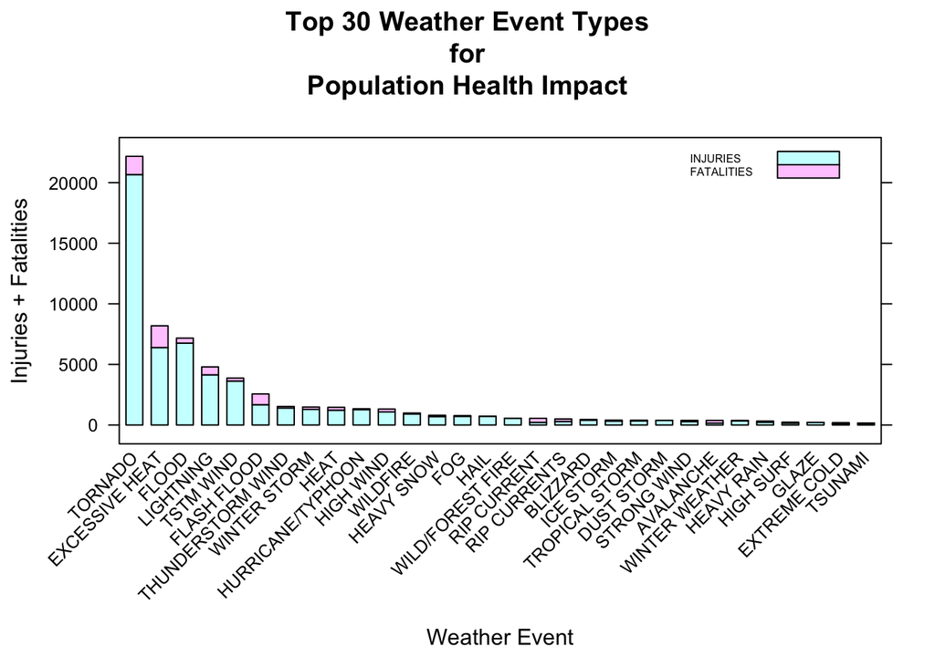

```r
plotHealth <- head(stormDataAggSortHealth, 30)
barchart(INJURIES+FATALITIES~reorder(EVTYPE,-HTHTOT), stack=TRUE, data=plotHealth,
         ylab = "Injuries + Fatalities", xlab = "Weather Event",
         main = "Top 30 Weather Event Types\nfor\nPopulation Health Impact",
         auto.key = list(corner=c(0.95,0.95), cex=.5),
         scales = list(x=list(rot = 45)))
```

As can be seen in the above stacked bar chart, the impact on population health by TORNADOs is almost 3 times as much as next major impact type of event, EXCESSIVE HEAT. Flood events, and storm related events make up the majority of the remaining top 5 major impact events, in regards to population health.

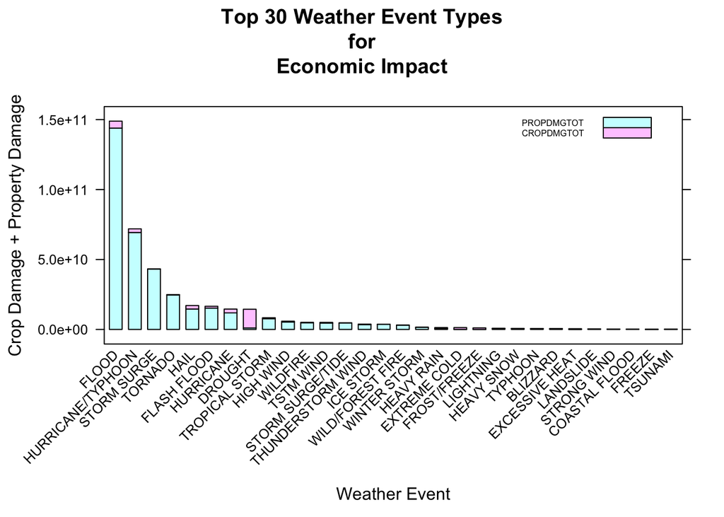

```r
plotEconomy <- head(stormDataAggSortEconmy, 30)
barchart(PROPDMGTOT+CROPDMGTOT~reorder(EVTYPE,-DMGTOT), stack=TRUE, data=plotEconomy,
          ylab = "Crop Damage + Property Damage", xlab = "Weather Event",
         main = "Top 30 Weather Event Types\nfor\nEconomic Impact",
         auto.key = list(corner=c(0.95,0.95), cex=.5),
         scales = list(x=list(rot = 45)))
```

As can be seen in the above stacked bar chart, the economic impact by Flood events is almost twice that of the next biggest impact event being Hurricane/Typhoons and then Storm Surge.

As previously suggested, many of these events could be grouped into “like” type events which would give even stronger evidence of event impact.

END